# Wie findet man ein Zentrum?

Ina Krapp

ina.krapp@freenet.de

01.10.2026

## Das Gefühl der Zentralität

- Wir alle haben eine Vorstellung eines Stadtzentrums
- Aber **was** macht einen Ort zentral?

**Code anzeigen**

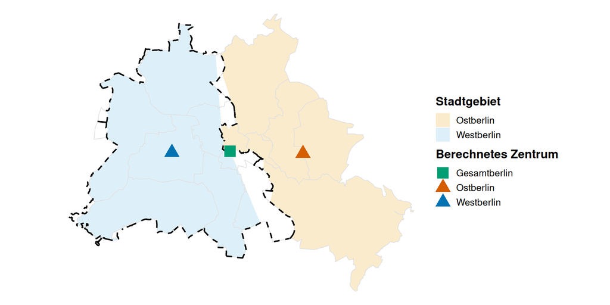

```r
# Pakete laden
library(tidyverse)
library(readxl)
library(sf)
library(here)
library(ggspatial)
library(nngeo)  # für st_connect

# Paket laden von github:
# install.packages("pak")
pak::pak("InaKrapp/sfhoneycombs")
pak::pak("InaKrapp/sfcentralities")
library(sfcentralities)
library(sfhoneycombs)

# 1. Geodaten laden (Bezirksgrenzen und Berliner Mauer)
Bezirksgrenzen <- st_read("https://github.com/InaKrapp/Workshops/raw/refs/heads/main/Zentrum/Bezirksgrenzen.gpkg", quiet = TRUE)
Grenzmauer <- st_read("https://github.com/InaKrapp/Workshops/raw/refs/heads/main/Zentrum/Grenzmauer.gpkg", quiet = TRUE)

# Die Mauer-Geometrie aufbereiten:
# Extraktion reiner Linien (LINESTRING) aus einer eventuell gemischten Geometrie (Compoundcurve)
Grenzmauer <- st_cast(Grenzmauer, "GEOMETRYCOLLECTION") %>%
  st_collection_extract("LINESTRING")


data_2023 = st_read("https://github.com/InaKrapp/Workshops/raw/refs/heads/main/Zentrum/IHKBerlin_Gewerbedaten_11-2023.gpkg", quiet = TRUE)

# 3. Daten bereinigen: Berliner Außengrenze holen
Berlin_Polygon <- Bezirksgrenzen %>% filter(text == "Berlin")

# Berliner Außengrenze für spätere Visualisierungen als Linie (MULTILINESTRING) speichern
Berlin <- st_cast(Berlin_Polygon, "MULTILINESTRING")



# --- 1. Flächen für Ost- und Westberlin generieren ---

# Mauer zu einer Linie zusammenführen
Grenzmauer_merged <- st_line_merge(st_union(st_geometry(Grenzmauer)))
# Alle Teilstücke einzeln verbinden (nächstgelegene Endpunkte je zwei Segmente)
teile <- st_cast(Grenzmauer_merged, "LINESTRING") %>% st_as_sf()
verbindungen <- nngeo::st_connect(teile, teile, k = 2, progress = FALSE) # verbindet nahegelegene Segmentenden

# Endpunkte der Mauer extrahieren
mauer_endpunkte <- st_line_sample(teile, sample = c(0, 1)) %>%
  st_cast("POINT")

# Nächstgelegene Punkte auf der Außengrenze finden
naechste_punkte <- st_nearest_points(mauer_endpunkte, Berlin)

alle_linien <- c(
  st_geometry(Berlin),
  st_geometry(teile),
  verbindungen,
  naechste_punkte
) %>% st_union()

# Jetzt erst polygonisieren
teil_polygone <- st_polygonize(alle_linien) %>%
  st_collection_extract("POLYGON") %>%
  st_as_sf()

teil_polygone$area <- st_area(teil_polygone)
teil_polygone <- teil_polygone %>% arrange(desc(area)) %>% slice(1:2)

mittelpunkte <- st_coordinates(st_centroid(teil_polygone))
teil_polygone$region <- ifelse(
  mittelpunkte[,1] == max(mittelpunkte[,1]),
  "Ostberlin",
  "Westberlin"
)


# --- 2. Punkte in den Flächen sampeln ---
set.seed(42) # Sorgt dafür, dass bei jedem Rendern exakt dieselben Punkte entstehen

pts_gesamt <- st_sample(Berlin_Polygon, size = 2000) %>%
  st_as_sf() %>% mutate(region = "Gesamtberlin")

pts_west <- st_sample(filter(teil_polygone, region == "Westberlin"), size = 2000) %>%
  st_as_sf() %>% mutate(region = "Westberlin")

pts_ost <- st_sample(filter(teil_polygone, region == "Ostberlin"), size = 2000) %>%
  st_as_sf() %>% mutate(region = "Ostberlin")

# Alle gesampelten Punkte zu einem Datensatz zusammenfügen
alle_punkte <- bind_rows(pts_gesamt, pts_west, pts_ost)

# --- 3. Die drei Zentren berechnen ---
Zentren_Historisch <- alle_punkte %>%
  st_geo_median(group = "region")

# --- 4. Karte plotten ---
ggplot() +
  # Hintergrund: Die zwei Hälften leicht unterschiedlich einfärben
  geom_sf(data = teil_polygone, aes(fill = region), color = NA, alpha = 0.2) +

  # Bezirksgrenzen zur Orientierung
  geom_sf(data = Bezirksgrenzen, fill = NA, color = "#E0E0E0", linewidth = 0.3) +

  # Die Berliner Mauer einzeichnen
  geom_sf(data = Grenzmauer, color = "black", linewidth = 0.8, linetype = "dashed") +

  # Die berechneten Zentren plotten
  geom_sf(data = Zentren_Historisch, aes(color = name, shape = name), size = 6) +

  # Farben und Symbole anpassen
  scale_fill_manual(values = c("Ostberlin" = "#E69F00", "Westberlin" = "#56B4E9")) +
  scale_color_manual(values = c("Gesamtberlin" = "#009E73", "Ostberlin" = "#D55E00", "Westberlin" = "#0072B2")) +
  scale_shape_manual(values = c("Gesamtberlin" = 15, "Ostberlin" = 17, "Westberlin" = 17)) +

  # Design
  theme_void(base_size = 14) +
  labs(
    color = "Berechnetes Zentrum",
    shape = "Berechnetes Zentrum",
    fill = "Stadtgebiet"
  ) +
  theme(
    legend.position = "right",
    legend.title = element_text(face = "bold")
  )
```

## Das Zentrum als dichter Ort - Honigwabenkarten

**Code anzeigen**

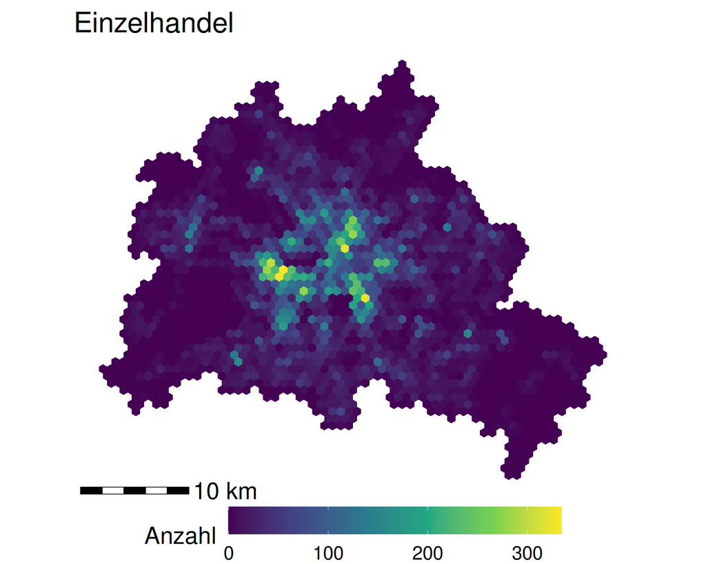

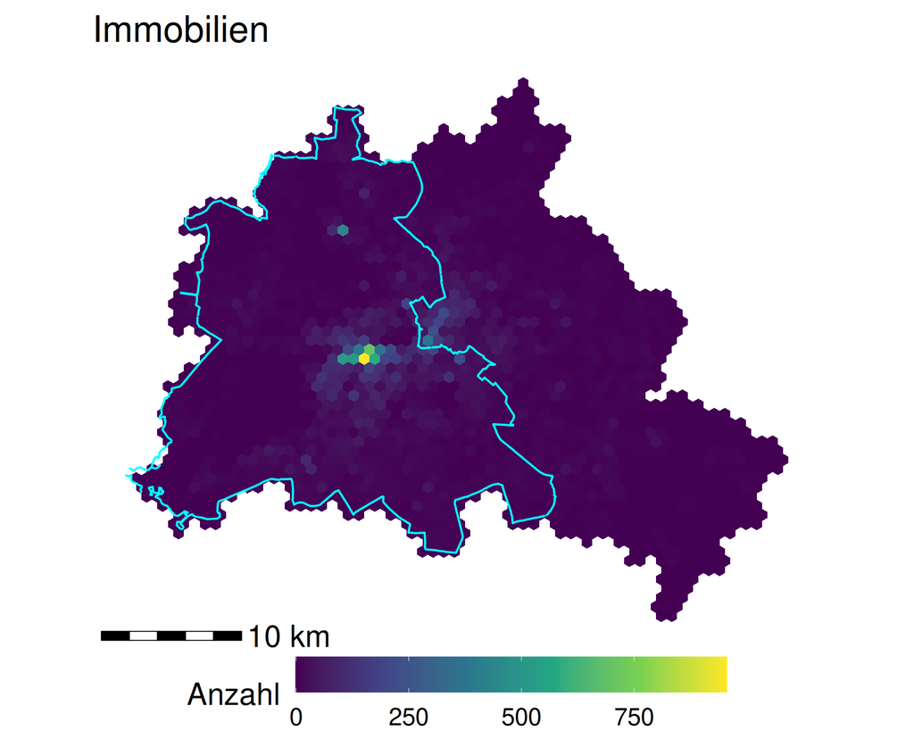

```r
# Die Option layout-ncol: 2 sorgt dafür, dass die folgenden zwei Plots
# sauber nebeneinander (in 2 Spalten) angeordnet werden.

# 1. Honigwaben-Karte für Branche 47 (z.B. Einzelhandel)
pts_47 <- dplyr::filter(data_2023, branch_top_level_id == 47)
map1 <- sfhoneycombs::st_create_honeycomb_map(Bezirksgrenzen, pts_47)

# Plot 1 rendern
ggplot() +
  geom_sf(data = map1, aes(fill = count), color = NA) +
  scale_fill_viridis_c(option = "viridis", direction = 1) + # Farbpalette viridis
  theme_void(base_size = 24) +
  labs(title = "Einzelhandel", fill = "Anzahl") +
  theme(legend.position = "bottom")+
  # Maßstab hinzufügen
  annotation_scale(location = "bl", width_hint = 0.25, text_cex = 2, style = "bar") +
      guides(fill = guide_colorbar(barwidth = unit(12, "cm"), barheight = unit(1, "cm")))
# 2. Honigwaben-Karte für Branche 68 (z.B. Immobilienwesen)
pts_68 <- dplyr::filter(data_2023, branch_top_level_id == 68)
map2 <- sfhoneycombs::st_create_honeycomb_map(Bezirksgrenzen, pts_68)

# Plot 2 rendern (mit Berliner Mauer als Overlay)
ggplot() +
  geom_sf(data = map2, aes(fill = count), color = NA) +
  geom_sf(data = Grenzmauer, color = "cyan", linewidth = 0.8) + # Mauer hervorgehoben
  scale_fill_viridis_c(option = "viridis", direction = 1) +
  theme_void(base_size = 24) +
  labs(title = "Immobilien", fill = "Anzahl") +
  theme(legend.position = "bottom")+
  # Maßstab hinzufügen
  annotation_scale(location = "bl", width_hint = 0.25, text_cex = 2, style = "bar") +
    guides(fill = guide_colorbar(barwidth = unit(12, "cm"), barheight = unit(1, "cm")))
```

## Das Zentrum als Ort geringer Entfernungen

Geometrischer Median: Punkt, von dem die Summe der Distanzen zu allen Punkten einer Gruppe minimal ist

**Code anzeigen**

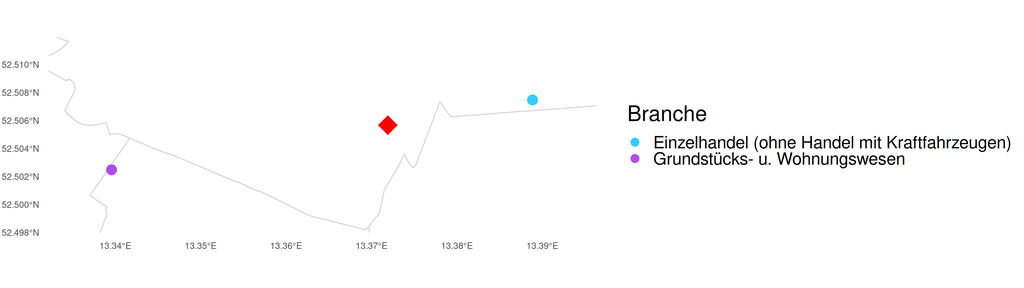

```r
# Paket laden
library(sfcentralities)

# 1. Geometrische Mediane berechnen
Berlin_Zentrum <- data_2023 %>% st_geo_median()
Berlin_Zentren <- data_2023 %>%
  st_geo_median(group = "branch_top_level_desc") %>%
  filter(number_of_points > 18000)

# 2. Dynamischen Zoom-Bereich berechnen
zentren_grenzen <- st_bbox(Berlin_Zentren)

# Nur noch einen kleinen geometrischen Puffer für die KARTE (nicht für die Legende!)
puffer <- 500  # 500 Meter in alle Richtungen

xlim <- c(zentren_grenzen["xmin"] - puffer, zentren_grenzen["xmax"] + puffer)
ylim <- c(zentren_grenzen["ymin"] - puffer, zentren_grenzen["ymax"] + puffer)

# 3. Visualisierung
ggplot() +
  geom_sf(data = Bezirksgrenzen, fill = "white", color = "#D3D3D3", linewidth = 0.5) +

  # Die gruppierten Branchen-Zentren
  geom_sf(data = Berlin_Zentren, aes(color = name), size = 5, alpha = 0.8) +

  # Das absolute Hauptzentrum
  geom_sf(data = Berlin_Zentrum, color = "red", size = 10, shape = 18) +

  # Den berechneten Zoom anwenden
  coord_sf(xlim = xlim, ylim = ylim, expand = FALSE) +

  # Base_size etwas erhöhen, damit die Schrift auf der Folie gut lesbar bleibt
  theme_minimal(base_size = 24) +
  labs(
    color = "Branche",
  ) +
  theme(
    legend.position = "right",
    # Entfernt überschüssige weiße Ränder um den Plot komplett:
    plot.margin = margin(t = 2, r = 2, b = 2, l = 2),
    axis.text = element_text(size = 10)
  ) +
  guides(color = guide_legend(override.aes = list(size = 4)))+
  scale_color_manual(values = c("deepskyblue", "purple"))
```

## Das Zentrum als vernetzter Ort

**Code anzeigen**

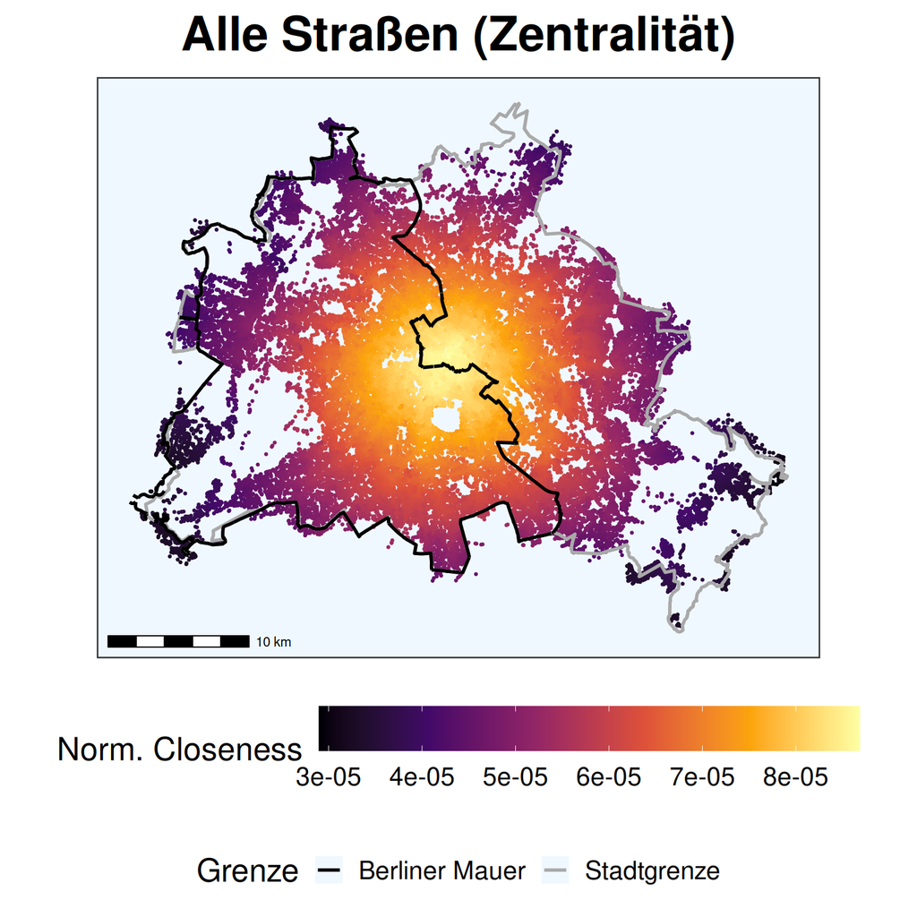

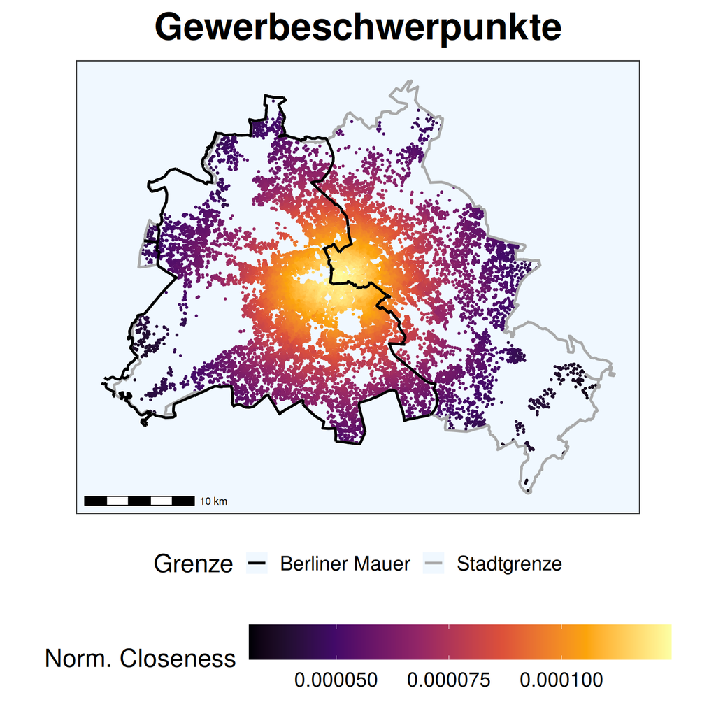

```r
# Daten einlesen (Closeness Centrality des Straßennetzwerks)
center_streetnet <- st_read("https://github.com/InaKrapp/Workshops/raw/refs/heads/main/Zentrum/streetnet_center.gpkg", quiet = TRUE)
firm_center_streetnet <- st_read("https://github.com/InaKrapp/Workshops/raw/refs/heads/main/Zentrum/firm_streetnet_center.gpkg", quiet = TRUE)


# Funktion zur Vermeidung von Code-Duplikaten beim Plotten
# Da beide Plots fast identisch formatiert sind, definieren wir das Theme einmalig
plot_network <- function(network_data, title) {
  ggplot()+

    # Straßennetzwerk basierend auf Zentralität (Closeness) einfärben
    geom_sf(data = network_data, aes(color = closeness), size = 0.5) +

    # Grenzen einfügen
    geom_sf(data = Berlin, aes(linetype = "Stadtgrenze"), color = "darkgrey", fill = NA, linewidth = 1) +
    geom_sf(data = Grenzmauer, aes(linetype = "Berliner Mauer"), color = "black", linewidth = 1) +

    # Maßstab hinzufügen
    annotation_scale(location = "bl", width_hint = 0.25, text_cex = 0.7, style = "bar") +

    # Farben und Legenden anpassen
    scale_linetype_manual(values = c("Berliner Mauer" = "solid", "Stadtgrenze" = "solid")) +
    scale_color_viridis_c(option = "inferno") + # Gute Sichtbarkeit
    labs(title = title, color = "Norm. Closeness", linetype = "Grenze") +

    # Design anpassen
    theme_bw(base_size = 20) +
    theme(
      panel.background = element_rect(fill = "aliceblue", color = NA),
      panel.grid = element_blank(),
      axis.title = element_blank(),
      axis.text = element_blank(),
      axis.ticks = element_blank(),
      legend.position = "bottom",
      legend.direction = "horizontal",
      legend.box = "vertical",
      plot.title = element_text(size = 30, face = "bold", hjust = 0.5)
    ) +
    guides(color = guide_colorbar(barwidth = unit(12, "cm"), barheight = unit(1, "cm")))
}

# Beide Plots aufrufen (werden durch layout-ncol: 2 nebeneinander dargestellt)
plot_network(center_streetnet, "Alle Straßen (Zentralität)")
plot_network(firm_center_streetnet, "Gewerbeschwerpunkte")
```

## Referenzen & Daten

- **R Core Team.** (2026). *R: A Language and Environment for Statistical Computing*. R Foundation for Statistical Computing. [DOI](https://doi.org/10.32614/R.manuals)

### R-Pakete:

- **Wickham, H., et al.** (2019). Welcome to the tidyverse. *Journal of Open Source Software*, *4*(43), 1686. [DOI](https://doi.org/10.21105/joss.01686)
- **Dunnington, D.** (2025). *ggspatial: Spatial Data Framework for ggplot2*. Version 1.1.10. CRAN. [DOI](https://doi.org/10.32614/CRAN.package.ggspatial)
- **Dorman, M.** (2024). *nngeo: k-Nearest Neighbor Join for Spatial Data*. Version 0.4.8. CRAN. [DOI](https://doi.org/10.32614/CRAN.package.nngeo)
- **Mark, P.** (2019). *dodgr: An R Package for Network Flow Aggregation*. *Transport Findings*, *2*(14). [DOI](https://doi.org/10.32866/6945)
- **Müller, K.** (2025). *here: A Simpler Way to Find Your Files*. Version 1.0.2. CRAN. [DOI](https://doi.org/10.32614/CRAN.package.here)
- **Krapp, I.** (2026). *sfcentralities: Centrality Measures for sf Objects*. Version 0.1.0. GitHub. [URL](https://github.com/InaKrapp/sfcentralities)
- **Krapp, I.** (2026). *sfhoneycombs: Create Honeycomb Maps Easily and Automatically from sf Objects*. Version 0.1.0. GitHub. [URL](https://github.com/InaKrapp/sfhoneycombs)
- **Pebesma, E., & Bivand, R.** (2023). *Spatial Data Science: With Applications in R*. Chapman and Hall/CRC. [DOI](https://doi.org/10.1201/9780429459016)
- **Pebesma, E.** (2018). Simple features for R: Standardized support for spatial vector data. *The R Journal*, *10*(1), 439–446. [DOI](https://doi.org/10.32614/RJ-2018-009)

### Daten:

- **Forum für Geschichte und Gegenwart e.V., Bauen und Wohnen Berlin, & Senatsverwaltung für Stadtentwicklung.** (2007). *Verlauf Der Berliner Mauer, 1989*. https://gdi.berlin.de/geonetwork/srv/ger/catalog.search#/metadata/3dcda64c-432d-3ac1-b28c-0b2f951bd242
- **Industrie- und Handelskammer (IHK) Berlin.** (2023). *Open Data - Gewerbedaten Berlin*. IHK Berlin. https://cloud.ihk.berlin/d/62fad06b540745098ab7/
- **Senatsverwaltung für Stadtentwicklung, Bauen und Wohnen Berlin.** (2025). *Verwaltungseinheiten Im INSPIRE-Datenmodell*. https://gdi.berlin.de/geonetwork/srv/ger/catalog.search#/metadata/1cc18674-2a0c-36e3-aba3-f34a54c0d844